# R Notebook

# Gene expressions in human dorsolateral prefrontal cortex(DL-PFC) from prenatal to adulthood stages

### Introduction

To create data frame “e”, tissue processing and dissection is needed firstly([5](http://help.brain-map.org/download/attachments/3506181/Transcriptome_Profiling.pdf?version=1&modificationDate=1382036562736)). RNA extraction, mRNA library preparation and sequencing, RNA sequencing alignment, Reads processing and quality filtering and Measuring Expression are the following steps to construct the data.([5](http://help.brain-map.org/download/attachments/3506181/Transcriptome_Profiling.pdf?version=1&modificationDate=1382036562736))

BrainSpan which is an atlas of the developing human brain is the referencen material of Data frame “g”.

As for sample information, brains were collected from individuals ranging from 8 post-conceptional weeks(pcw) to 40 years of age to ensure that except for embryonic stage, all developmental and adult stages were included.([5](http://help.brain-map.org/download/attachments/3506181/Transcriptome_Profiling.pdf?version=1&modificationDate=1382036562736)) Samples were categorized into different stages based upon age and major neurodevelopmental milestones.([5](http://help.brain-map.org/download/attachments/3506181/Transcriptome_Profiling.pdf?version=1&modificationDate=1382036562736)) Prenatal age was extrapolated based upon the date of the mother’s last menstruation, characteristics of the fetus noted upon ultrasonographic scanning, and foot length of the fetus.([5](http://help.brain-map.org/download/attachments/3506181/Transcriptome_Profiling.pdf?version=1&modificationDate=1382036562736))

Here I chose 8 genes for plotting. **Myelin-associated basic protein (MOBP)**, **myelin-associated glycoprotein (MAG)**, **2’,3’-cyclic nucleotide 3’-phosphodiesterase (CNP)** and **oligodendrocyte-lineage transcription factor2 (OLIG2)** which are oligodendrocyte-associated genes in DLPFC. Decreased mRNA expression of these genes are found in patients with schizophrenia([Mitkus, Shruti N., et al. 2008](https://www.ncbi.nlm.nih.gov/pmc/articles/PMC2259271/)). The others are **CSMD1**, **C10orf26**, **CACNA1C** and **TCF4**. A recently completed genome-wide association study (GWAS) implicated single-nucleotide polymorphisms in the MIR137 gene as being highly associated with schizophrenia which encodes for the microRNA miR-137([Ripke, Stephan, et al. 2011](https://www.nature.com/articles/ng.940)). miR-137 has been implicated in the regulation of adult neurogenesis([Szulwach, Keith E., et al. 2010](http://jcb.rupress.org/content/189/1/127.short)) and neuron maturation([Smrt, Richard D., et al. 2010](https://stemcellsjournals.onlinelibrary.wiley.com/doi/full/10.1002/stem.431)). And CSMD1, C10orf26, CACNA1C and TCF4 are regulated by miR-137([Kwon et al. 2013](https://www.nature.com/articles/mp2011170)). Thus, patients with schizophrenia should express lower levels of these genes.

```r
#load('~/Downloads/data_brainspan_DFC.20190928.Rdata')
library(tidyr)
library(tidyverse)
library(dplyr)
library(ggplot2)
library(cowplot)
```

```r
# add a new column named "row_num" to the dataframe "e"
e<-e%>%
  mutate(row_num=1:52376)
```

```r
# convert the wide format dataframe "e" to a long format dataframe "e1"
e1 <- gather(e, column_num, expression_level, X1:X35, factor_key=TRUE)
```

```r
# remove all X from the dataframe "e1" in column "column_num"
e1<- e1%>%
  mutate(column_num=gsub("X","",e1$column_num))
```

```r
# merge two dataframes "e1" and "g" to a dataframe named "eg"
eg<-merge(e1, g, by="row_num")
```

```r
# merge two dataframes "eg" and "s" to a dataframe named "esg"
esg<-merge(eg, s, by="column_num")
```

```r
# change the name of columns in "esg" from " column_num" to "sample_num" and "row_num" to "gene_num"
colnames(esg)[1]<- ("sample_num")
colnames(esg)[2]<-("gene_num")
```

```r
# add two new columns "Developmental_period" and "Stage" according to sample's age
esg<- esg%>%
  mutate(Developmental_period=case_when(
    age%in%c("8 pcw", "9 pcw","12 pcw")~"early prenatal" ,
    age%in%c("13 pcw","16 pcw","17 pcw")~"early mid-prenatal",
    age%in%c("19 pcw","21 pcw","24 pcw")~"late mid-prenatal",
    age%in%c("26 pcw", "37 pcw")~"late prenatal",
    age == "4 mos" ~ "early infancy",
    age=="10 mos" ~ "late infancy",
    age %in% c("1 yrs","2 yrs","3 yrs","4 yrs") ~ "early childhood",
    age %in% c("8 yrs","11 yrs") ~ "late childhood",
    age %in% c("13 yrs","18 yrs","19 yrs") ~ "adolescence",
    TRUE ~ "adulthood"
  ))
esg<-esg%>%
  mutate(Stage=case_when(
    age%in%c("8 pcw", "9 pcw") ~ "2A",
    age=="12 pcw" ~ "2B",
    age=="13 pcw" ~ "3A",
    age%in%c("16 pcw","17 pcw") ~ "3B",
    age%in%c("19 pcw","21 pcw","24 pcw")~ "4",
    age%in%c("26 pcw", "37 pcw")~ "5",
    age == "4 mos" ~ "6",
    age=="10 mos" ~ "7",
    age %in% c("1 yrs","2 yrs","3 yrs","4 yrs") ~ "8",
    age %in% c("8 yrs","11 yrs") ~ "9",
    age %in% c("13 yrs","18 yrs","19 yrs") ~ "10",
    TRUE ~ "11"
  ))
```

```r
# convert dataframe "esg" to a tibble dataframe
esg<-as_tibble(esg)
```

```r
# mutate sample_num data to become numeric for reordering
esg<-esg%>%
  mutate(sample_num=as.numeric(sample_num))
```

```r
# filter rows with several genes(MOBP,CNP,MAG,OLIG2)
multiple1<-esg%>%
  filter(gene_symbol%in%c("MOBP", "CNP","MAG","OLIG2")&expression_level>0.0&age%in%c("11 yrs", "13 yrs", "18 yrs", "19yrs","21 yrs", "30 yrs"))
```

```r
multiple2<- esg%>%
  filter(gene_symbol%in%c("CSMD1", "C10orf26", "CACNA1C","TCF4")&expression_level>0.0)
```

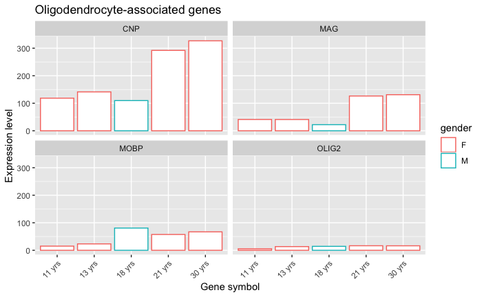

```r
# comparing expression levels of several genes from early prenatal to adulthood by sex
a<-multiple1%>%
   mutate(age = reorder(age, sample_num)) %>%
  ggplot(aes(age,expression_level, col=gender)) +
  geom_bar(stat="identity", fill="white")+
  theme(axis.text.x = element_text(angle = 45, hjust = 1))+
  facet_wrap(~gene_symbol)+
  xlab("Gene symbol")+
  ylab("Expression level")+
  ggtitle("Oligodendrocyte-associated genes")
a
```

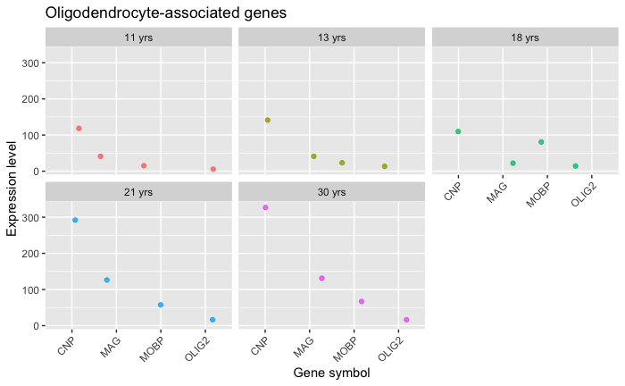

```r
# comparing expression levels of several genes from early prenatal to adulthood by sex
b<-multiple1%>%
  mutate(age=reorder(age, sample_num))%>%
  ggplot(aes(gene_symbol, expression_level))+
  geom_jitter(alpha = 0.8,aes(color=age), show.legend = FALSE)+
  facet_wrap(~age, ncol=3)+
  theme(axis.text.x = element_text(angle = 45, hjust = 1))+
  xlab("Gene symbol")+
  ylab("Expression level")+
  ggtitle("Oligodendrocyte-associated genes")
b
```

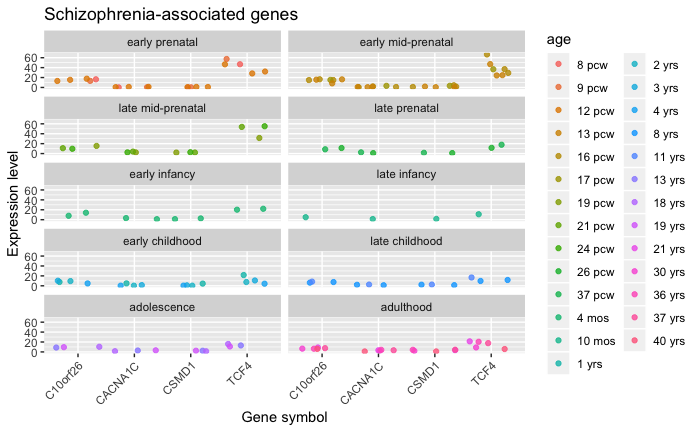

```r
# comparing expression levels of several genes from 8pcw to 40yrs with developmental period
c<-multiple2%>%
  mutate(age=reorder(age, sample_num))%>%
  mutate(Developmental_period=reorder(Developmental_period, sample_num))%>%
  ggplot(aes(gene_symbol, expression_level))+
  geom_jitter(alpha = 0.8,aes(color=age))+
  facet_wrap(~Developmental_period, ncol=2)+
  theme(axis.text.x = element_text(angle = 45, hjust = 1))+
  xlab("Gene symbol")+
  ylab("Expression level")+
  ggtitle("Schizophrenia-associated genes")
c
```

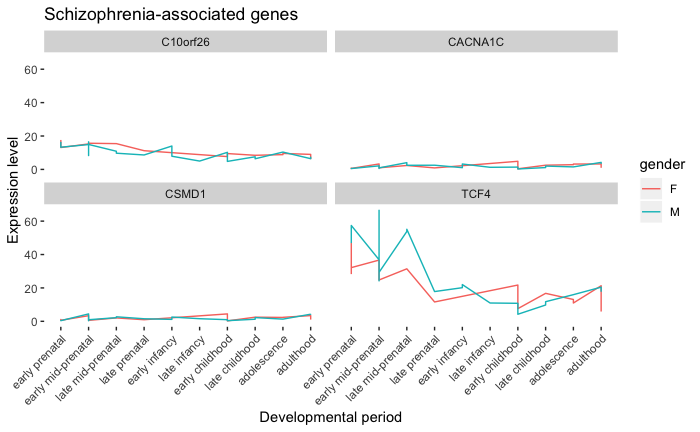

```r
d<-multiple2%>%
   mutate(Developmental_period = reorder(Developmental_period, sample_num)) %>%
  ggplot(aes(Developmental_period,expression_level, group=gender))+
  geom_line(position = "identity", aes(color=gender))+
  theme(axis.text.x = element_text(angle = 45, hjust = 1))+
  facet_wrap(~gene_symbol, nrow=2)+
  theme(panel.background = element_rect("white"))+
  xlab("Developmental period")+
  ylab("Expression level")+
  ggtitle("Schizophrenia-associated genes")
d
```

```r
x<-plot_grid(a,b,labels=c('A', 'B'), ncol=2)
ggsave("plot.assignment1.BrainSpan_dataset.expression_level_of_Oligodendrocyte_associated_genes_191016.pdf", x)
```

```r
ggsave("plot.assignment1.jitter_BrainSpan_dataset.expression_level_of_Schizophrenia_associated_genes_191016.pdf", c)
ggsave("plot.assignment1.line_BrainSpan_dataset.expression_level_of_Schizophrenia_associated_genes_191016.pdf", d)
```

### Conclusion

Schizophrenia can occur at any age, the average age of onset tends to be in the late teens to the early 20s for men, and the late 20s to early 30s for women.Since there are no sample shows particular low expression levels of Oligodendrocyte-associated genes, we can assume that there are no patient with Schizophrenia.

# References

1. Mitkus, Shruti N., et al. “Expression of oligodendrocyte-associated genes in dorsolateral prefrontal cortex of patients with schizophrenia.” *Schizophrenia research* 98.1-3 (2008): 129-138.
2. Kwon, E., W. Wang, and L. H. Tsai. “Validation of schizophrenia-associated genes CSMD1, C10orf26, CACNA1C and TCF4 as miR-137 targets.” *Molecular psychiatry* 18.1 (2013): 11.
3. Ripke, Stephan, et al. “Genome-wide association study identifies five new schizophrenia loci.” *Nature genetics* 43.10 (2011): 969.
4. Szulwach, Keith E., et al. “Cross talk between microRNA and epigenetic regulation in adult neurogenesis.” *The Journal of cell biology* 189.1 (2010): 127-141.
5. *TECHNICAL WHITE PAPER: TRANSCRIPTOME PROFILING BY RNA SEQUENCING AND EXON MICROARRAY* http://help.brain-map.org/download/attachments/3506181/Transcriptome_Profiling.pdf?version=1&modificationDate=1382036562736.